# DETERMINING THE CAUSAL LINKS BETWEEN REPRODUCTIVE TIMING AND METABOLIC RISK: A BIDIRECTIONAL MENDELIAN RANDOMIZATION STUDY

### 5.9.1 **Reverse Multivariable MR (MVMR)**

Direction: Lipids + BMI → ANM  
Exposures: HDL, LDL, TG and TC , Body Mass Index  
Outcome: ANM  
Research Question: Do lipid levels influence ANM independent of BMI? and does BMI affect the each lipid level independent of ANM.

```r
######################################################
# Reverse Multivariable MR: Lipids + BMI → ANM
######################################################

#Exposures = Lipids + BMI
exp_mvmr_lipids_to_anm_bmi <- mv_extract_exposures(
  id_exposure = c(
    lipids,   # lipids
    "ieu-a-2" # BMI
  ),
  clump_r2 = 0.001,
  clump_kb = 10000,
  pop = "EUR"
)
```

```
Please look at vignettes for options on running this locally if you need to run many instances of this command.
```

```
Clumping 1, 330 variants, using EUR population reference
```

```
Removing 144 of 330 variants due to LD with other variants or absence from LD reference panel
```

```
Extracting data for 186 SNP(s) from 5 GWAS(s)
```

```
Querying id chunk 1 of 1
```

[output not shown]

[output not shown]

[output not shown]

[output not shown]

[output not shown]

[output not shown]

[output not shown]

[output not shown]

[output not shown]

[output not shown]

[output not shown]

[output not shown]

[output not shown]

[output not shown]

[output not shown]

[output not shown]

```
Finding proxies for 1 SNPs in outcome ebi-a-GCST002222
```

```
Extracting data for 1 SNP(s) from 1 GWAS(s)
```

```
Querying id chunk 1 of 1
```

```
Querying variant chunk 1 of 1
```

```
Finding proxies for 1 SNPs in outcome ebi-a-GCST002223
```

```
Extracting data for 1 SNP(s) from 1 GWAS(s)
```

```
Querying id chunk 1 of 1
```

```
Querying variant chunk 1 of 1
```

```
Finding proxies for 2 SNPs in outcome ebi-a-GCST002216
```

```
Extracting data for 2 SNP(s) from 1 GWAS(s)
```

```
Querying id chunk 1 of 1
```

```
Querying variant chunk 1 of 1
```

```
Finding proxies for 1 SNPs in outcome ebi-a-GCST002221
```

```
Extracting data for 1 SNP(s) from 1 GWAS(s)
```

```
Querying id chunk 1 of 1
```

```
Querying variant chunk 1 of 1
```

```
Finding proxies for 2 SNPs in outcome ieu-a-2
```

```
Extracting data for 2 SNP(s) from 1 GWAS(s)
```

```
Querying id chunk 1 of 1
```

```
Querying variant chunk 1 of 1
```

```
Harmonising LDL cholesterol || id:ebi-a-GCST002222 (ebi-a-GCST002222) and Triglycerides || id:ebi-a-GCST002216 (ebi-a-GCST002216)
```

```
Removing the following SNPs for being palindromic with intermediate allele frequencies:
rs14810, rs17001654, rs3758348, rs378479, rs7534572, rs9491696, rs9914578
```

```
Harmonising LDL cholesterol || id:ebi-a-GCST002222 (ebi-a-GCST002222) and Cholesterol, total || id:ebi-a-GCST002221 (ebi-a-GCST002221)
```

```
Removing the following SNPs for being palindromic with intermediate allele frequencies:
rs14810, rs17001654, rs3758348, rs378479, rs7534572, rs9491696, rs9914578
```

```
Harmonising LDL cholesterol || id:ebi-a-GCST002222 (ebi-a-GCST002222) and HDL cholesterol || id:ebi-a-GCST002223 (ebi-a-GCST002223)
```

```
Removing the following SNPs for being palindromic with intermediate allele frequencies:
rs14810, rs17001654, rs3758348, rs378479, rs7534572, rs9491696, rs9914578
```

```
Harmonising LDL cholesterol || id:ebi-a-GCST002222 (ebi-a-GCST002222) and Body mass index || id:ieu-a-2 (ieu-a-2)
```

```
Removing the following SNPs for being palindromic with intermediate allele frequencies:
rs14810, rs17001654, rs3758348, rs378479, rs9491696, rs9914578
```

```r
#Outcome = ANM
out_mvmr_lipids_to_anm_bmi <- extract_outcome_data(
  snps     = exp_mvmr_lipids_to_anm_bmi$SNP,
  outcomes = "ieu-a-1004"
)
```

```
Extracting data for 176 SNP(s) from 1 GWAS(s)
```

```
Querying id chunk 1 of 1
```

```
Querying variant chunk 1 of 3
```

```
Querying variant chunk 2 of 3
```

```
Querying variant chunk 3 of 3
```

```
Finding proxies for 5 SNPs in outcome ieu-a-1004
```

```
Extracting data for 5 SNP(s) from 1 GWAS(s)
```

```
Querying id chunk 1 of 1
```

```
Querying variant chunk 1 of 1
```

```r
#Harmonise
mvmr_dat_lipids_to_anm_bmi <- mv_harmonise_data(
  exposure_dat = exp_mvmr_lipids_to_anm_bmi,
  outcome_dat  = out_mvmr_lipids_to_anm_bmi
)
```

```
Harmonising LDL cholesterol || id:ebi-a-GCST002222 (ebi-a-GCST002222) and Age at menopause || id:ieu-a-1004 (ieu-a-1004)
```

```r
#Run multivariable MR
res_mvmr_lipids_to_anm_bmi <- mv_multiple(mvmr_dat_lipids_to_anm_bmi)
res_mvmr_lipids_to_anm_bmi$result
```

```
       id.exposure                                  exposure id.outcome
1 ebi-a-GCST002216      Triglycerides || id:ebi-a-GCST002216 ieu-a-1004
2 ebi-a-GCST002221 Cholesterol, total || id:ebi-a-GCST002221 ieu-a-1004
3 ebi-a-GCST002222    LDL cholesterol || id:ebi-a-GCST002222 ieu-a-1004
4 ebi-a-GCST002223    HDL cholesterol || id:ebi-a-GCST002223 ieu-a-1004
5          ieu-a-2             Body mass index || id:ieu-a-2 ieu-a-1004
                            outcome nsnp          b        se      pval
1 Age at menopause || id:ieu-a-1004   35 -0.1684315 0.3673050 0.6465500
2 Age at menopause || id:ieu-a-1004   67  0.9683181 0.9968569 0.3313634
3 Age at menopause || id:ieu-a-1004   53 -0.9215895 0.8679854 0.2883461
4 Age at menopause || id:ieu-a-1004   69 -0.4519502 0.4398711 0.3042037
5 Age at menopause || id:ieu-a-1004   51 -0.1394662 0.1631868 0.3927496
```

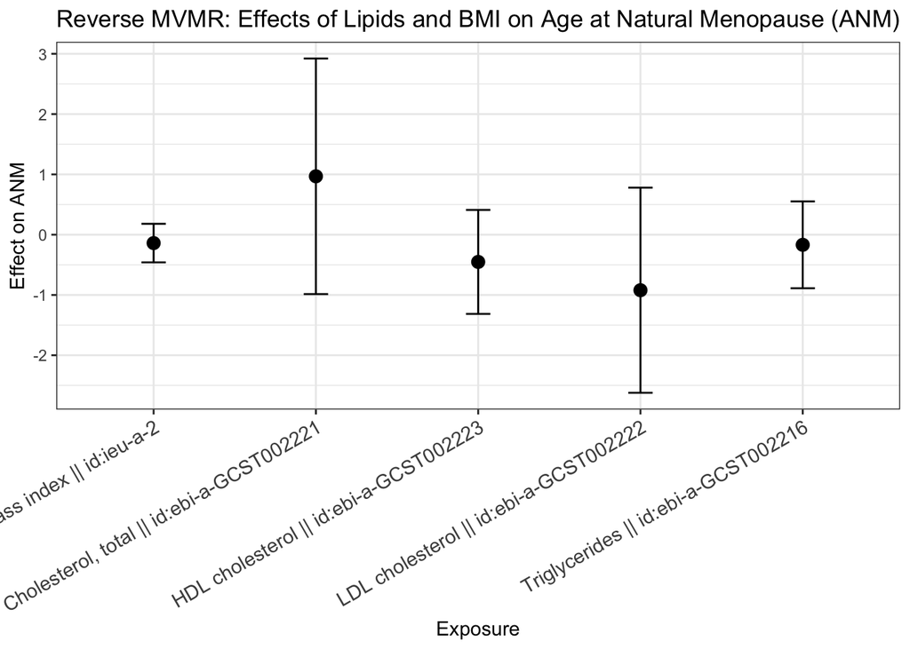

```r
#Plot reverse MVMR

ggplot(res_mvmr_lipids_to_anm_bmi$result, aes(x = exposure, y = b)) +
  geom_point(size = 3) +
  geom_errorbar(
    aes(ymin = b - 1.96 * se, ymax = b + 1.96 * se),
    width = 0.15
  ) +
  theme_bw() +
  theme(
    axis.text.x = element_text(angle = 30, hjust = 1, size = 11)
  ) +
  labs(
    title = "Reverse MVMR: Effects of Lipids and BMI on Age at Natural Menopause (ANM)",
    x = "Exposure",
    y = "Effect on ANM"
  )
```

#### 5.9.1.1 Results for Reverse MVMR (Lipids + BMI → ANM)

| Exposure | SNPs | β | SE | p-value | Interpretation |
| --- | --- | --- | --- | --- | --- |
| Triglycerides (TG) | 35 | -0.1684 | 0.3673 | 0.6466 | Not significant |
| Total Cholesterol (TC) | 67 | 0.9683 | 0.9969 | 0.3314 | Not significant |
| LDL Cholesterol | 53 | -0.9216 | 0.8680 | 0.2883 | Not significant |
| HDL Cholesterol | 69 | -0.4520 | 0.4399 | 0.3042 | Not significant |
| Body Mass Index (BMI) | 51 | -0.1395 | 0.1632 | 0.3927 | Not significant |

Conclusion: No evidence that increase in Lipid levels, even after adjusting for BMI influence the menopause timing

# 6 **Conclusion**

This study investigated the causal links between reproductive timing—age at menarche (AAM) and age at natural menopause (ANM)—and major metabolic traits, including type 2 diabetes (T2D), lipid levels (HDL, LDL, triglycerides, total cholesterol), and BMI. Overall, the findings provide strong evidence that BMI is the key driver linking reproductive timing and metabolic risk, while AAM and ANM themselves show limited or trait-specific causal effects with the exception of AAM influencing HDL. Therefore, we can conclude that AAM and ANM are not reliable standalone predictors of T2D or lipid disorders when considered independently of BMI. BMI should be prioritized as a modifiable risk factor in the prevention of early puberty and metabolic disease. AAM may be useful as an early-life indicator of metabolic vulnerability, but mainly because it reflects underlying adiposity rather than reproductive biology. These findings suggest that reproductive timing reflects underlying metabolic risk largely through adiposity rather than direct hormonal mechanisms.

**Limitations**

Several multivariable Mendelian randomization analyses could not be performed due to insufficient SNP overlap following harmonisation. While forward Mendelian randomization analyses were successful, reverse and multivariable analyses required genetic variants to be simultaneously associated with multiple exposures and present in the outcome GWAS. Reproductive timing traits such as age at menarche and age at natural menopause are highly polygenic, whereas lipid traits and type 2 diabetes share fewer genome-wide significant variants with these traits. As a result, the intersection of valid instruments across all datasets was limited, leading to harmonisation failure. This reflects differences in genetic architecture rather than methodological error and highlights a known limitation of multivariable MR when applied to complex traits.

Strong heterogeneity in many models suggests biological complexity and possible balanced pleiotropy. Meaning that the genetic variants affect the outcome through other pathway than through the exposure, but these pleiotropic effects are random and cancel out in average. The results are specific to European-ancestry populations and it was difficult to find sex-stratified GWAS studies.

**Future directions**

- Replicate in other ancestries to see whether the causal effects are the same as what we have seen in this study.
- Explore the causal effects of reproductive timing with other cardiovascular traits and other metabolic traits.
- Investigate the multivariable hormonal modeling.
- Understand the biological mechanism of where we see positive causation.
- Explore other pleiotropy and heterogeneity methods
  - MR-PRESSO - detects and eliminates outlier SNPs driving pleiotropy.
  - CAUSE – models correlated pleiotropy.
  - Radial MR – identify variants influencing pleiotropy.